# Goldberg Gator Engineering Explorers Summer Program Planning Guide

The EQuIPD Grant at The University of Florida

2022-07-25

[figure not shown]

[figure not shown]

**Designed by:**

**The EQuIPD Grant at The University of Florida**

**Dr. Nancy Ruzycki, Dr. Krista Dulany, Dr. Lorelie Imperial**

**Contributing Authors: Olivia Lancaster, Areesha Razi, Michael Roberts, Karen Hart**

# 1 Planning Summer Programs

## 1.1 Administrative

- Contact the school district STEM or science department to offer an opportunity to host a summer program.
  - If you know a teacher that would like to host the summer program and has permission from their school principal to host the summer program, work with them and the school team.
- They should work with you to identify a target school to host the summer program if a school is not already in mind.
- Work with them to identify a school, classroom, essential personnel on-site with contact information, materials available, technology – computers and learning management software, summer program dates (four to five full days, or eight half days), meals, snacks, outdoor activities/equipment, emergency plans
- Develop fliers to advertise for the summer program in the target school(s). The flier should include the program dates, times, location, meals provided, a brief program description, and a link to the registration.

## 1.2 Compliance

- Parents must sign a permission slip or waiver to acknowledge their student’s participation in the program. We recommend that this permission form gets sent via email with the research consent form (see IRB Requirements) at least a week before the start of the summer program. Parents can sign and submit scanned copies of the form via email. Always have hard copies available on the first day of the program for parents to complete during student drop-off.
  - An example waiver for UF youth summer programs can be found in *Appendix A: Student Waiver*.
- Photo consent and release are required to be signed by the parents of students
- The addition of a behavior contract subsection to the consent form could be helpful
  - Agrees that parents and students should be on their best behavior
  - Provides a process for teachers to reach out to parents in the event of bad behavior
- Establish a clear sign-in and sign-out procedure that complies with school and organization requirements
  - School staff should be in charge of student dismissal
- Create a digital sign-in and out for internal records in addition to a paper sign-in and out
- **ALL PERSONS INTERACTING WITH STUDENTS MUST GO THROUGH THE PROPER COMPLIANCE MEASURES**
  - FERPA Training
  - Youth Protection Training
  - Level 2 Background Screening and Fingerprinting
  - Teacher badge credentials (if at home school location)
  - Blue State Vendor Badge (if outside home school)

## 1.3 Assessment

### 1.3.1 IRB - Assessment Plan

During the summer program, the study focused on assessing student motivation and identity as computer scientists and engineers when completing computer science-related activities throughout the program. This is done through surveys at the start of the program and at the end of each day, in addition to student interviews and observations. We also want to determine students’ skills and cognitive processes as they engage with CT and EDT.

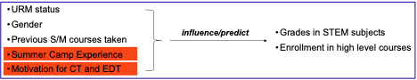

### 1.3.2 IRB Requirements

*Only if completing a research study*

### 1.3.3 No IRB – Assessment

Students understand norms for working together and how to treat and work with a Micro:bit Students are successful in programming basics

- understanding how to create a process map
- basic programming of a Micro:bit to make a name badge
- understanding logic in programming and how to code it
- troubleshooting and debugging
- problem-solving

Students can apply programming basics in designing a rock, paper, scissors game and use the Micro:bit to collect data to analyze using graphing software (excel, google sheets).

Students can navigate the design process and work with partners to develop a functional design for a Micro:bit pet and a technical design challenge.

## 1.4 Program Materials

### 1.4.1 Technology

- Computers for each student – laptops preferred, desktops work
- Students access to their student email
- Student access to LMS system – Microsoft Team, Google Classroom, etc.
- Internet restrictions
  - Students need access to https://makecode.microbit.org/#editor
- BBC Micro:bit V2 – one for each student
  - Students keep their Micro:bit
  - Order 5-6 months in advance, shipping time and availability vary
  - https://www.parallax.com/product-category/microbit/mb-modules/
- STEM Kit – Keyestudio 37-in-1 kit with the board is suggested
  - One kit per 2 students is recommended
  - https://www.amazon.com/KEYESTUDIO-Sensors-Box-Starter-Micro/dp/B07GSVHWNS/ref=sr_1_2?keywords=keyestudio%2B37%2Bin%2B1%2Bmicro%2Bbit&qid=1638303507&sr=8-2&th=1

| Technology | Craft Supplies | Activity Supplies |
| --- | --- | --- |
| Computers | Tape | Sticky Notes |
| Micro:bits - 1 per student | Paper | Sticky Easel Pad (optional) |
| Micro Servo motors | Markers | Rulers |
| Dupont Wires (male –female, male – male) | Pencils | Flashlight/cell phone for light lab |
| Alligator Clips | Scissors | Student Rewards |
| AAA Batteries | Construction paper |  |
| Micro:bit Stem Kits – sensors, LED lights, motors | Paper towel/toilet paper rolls |  |
|  | Cardboard/Cardstock |  |
|  | Other craft materials for design projects |  |

## 1.5 Student Registration

A digital student registration should be developed to allow parents to register their students. The survey needs to collect the following student and parent information:

- Student Full Name
- Student School Email
- Parent Full Name
- Parent Email
- Parent Phone Number
- Home Address
- Select Summer program Location and Dates (if multiple)
- Designated Pick-Up People
  - Contact Information (Phone Number)
  - Relation to Student
- Emergency Contact Information
  - Name, Relation, Phone Number
- Allergies – Food or Environmental

## 1.6 Program Leaders

Classroom teachers make great candidates for leading this summer program. It is something that teachers with little programming experience to a lot of programming experience can lead. This program also makes the transition of applying Micro:bits in the classroom more straightforward and more authentic in the application.

For the middle school age range, UF requires a ratio of one teacher for every ten students for a day program. We recommend that there need to be at least two adult teachers or paraprofessionals leading the program. The classroom experience is helpful when teaching a classroom of students through the program.

All teachers must complete the required training and credentialing to participate in and lead a summer program. Required training and credentials include:

- FERPA Training
- Youth Protection Training
- Level 2 Background Screening and Fingerprinting
- Teacher badge credentials (if at home school location)
- Blue State Vendor Badge (if outside home school)

The opportunity for high school students to volunteer can be arranged. You will need to work with the school and school district to ensure proper protocols and compliance measures are in place. This includes on-site school supervision, volunteer permission forms for parents to complete as they are minors, and appropriate training.

## 1.7 Learning Management Systems

We have found it helpful to distribute summer program materials using a learning management system. Students each get their copy of the activities to work on during the program activities. This allows summer program facilitators to see students work and check progress actively. We have used Microsoft Teams and Google Classroom to distribute student activity frameworks.

The summer program can be run without digital documents. The frameworks can be printed, or students can work on their paper with the activity instructions projected to the class.

## 1.8 Industry Connections

### 1.8.1 Mentor Recruitment

The summer program is designed to include a technical design challenge that is related to challenges seen in an industry environment. To do this authentically, schools, districts, and summer program organizers should invite employees from 3-4 local industries to present to the students. They should go over their company, what the industry does, their role, and their educational background. At the end of the presentation, the industry mentor will present a challenge or problem they see in their field that the students can solve by programming their Micro:bits.

### 1.8.2 Field Trips

We saw that most school districts operate on a four-day schedule during the summer. This meant that most summer programs were designed to be 4-day programs. This leaves the perfect opportunity to schedule an industry field trip or trips with the mentors that proposed the design challenges. Students and program leaders will get the chance to tour the company, see what they do in action, and how their design challenge solution works in the company that proposed the challenge.

# 2 Training for Facilitators

## 2.1 Training Expectations

To complete a Goldberg Gator Engineering Explorers Summer Program, the facilitators must understand what the program expectations are:

- Understand the purpose and goals of the program
- Understand the role of the facilitator of the program
- Be able to guide students through the program activities and help them acquire skills
- Understand the purpose of the icebreakers and what to focus on
- Facilitate group work and critical thinking
- Review the program activities to understand the meaning, leader, and student roles
- Practice Microsoft Micro:bit activities to be able to troubleshoot with students during the program

## 2.2 Tips for Success

- Stay organized. Organization is your lifeline in a program with so many moving parts
- Start training early (Roughly two months before your program starts)
- Use team bonding activities such as icebreakers and food socials to ensure that all teams of facilitators are ready to work with one another

## 2.3 How to Ensure that Facilitators Are on Task

Throughout training and programs, facilitators might get off task. To ensure that each facilitator has completed the training for the day, we recommend using Microsoft Teams or a similar platform to create daily/weekly assignments where the facilitators work through the activity guide, such as students would be doing during the program. The implementation of assignments makes an organized base for both the organizers of the program and the facilitators.

## 2.4 Training Schedule

To create a successful program, program organizers must provide training to facilitators. We recommend introducing the facilitators to the Microsoft Micro:bit two months before the program begins. This ensures they are familiar with the device and are prepared to teach the students. We also recommend a 4-week bootcamp which makes the facilitators go through the program activity guide, such as what the students would be doing during the program. Program organizers should how a meeting once a week (or more, depending on the facilitators) where they go through the program expectations, program activities, logistical information, and more.

**Office Hours**

Facilitators might have questions on different Micro:bit activities or program days throughout the training. Hosting office hours is highly recommended to ensure all facilitator questions are answered. Program organizers should schedule 1-3 office hours each week. The program organizer should put these questions and answers in a separate document to send out to the team in case other facilitators might have the question later.

## 2.5 Summer Program Content

The program will be going through Microsoft Micro:bit activities and projects. An activity guide has already been created with a step-by-step schedule for each program day and related activities. We have mapped out three layouts of the program composed of a full day, 7-hour, or half day, 4-hour programs. All of the facilitator guides can be found under the Facilitator Guides section.

## 2.6 Logistical Components of the Programs

**Surveys**

If you are running a research study, the facilitators must administer surveys that help track the students’ progress, excitement, and quality of work in the programs. To ensure surveys are correctly administered, please follow the guide below:

- Every Day: Sign In and Sign Out Surveys and End of Day Survey (this survey will not be issued on the last day of the program)
- First Day of Program: Pre-survey
- Last Day of Program: End of Program Survey

**Consent Forms**

Reference the Compliance and Assessment sections for more information. Facilitators are also responsible for distributing, collecting, and organizing forms such as consent forms from the student and parent, research waivers, and any other forms the participating districts might require. For best results, we recommend sending digital copies of the forms one week before the start of the program and organizing which students/parents have completed the forms. You should also print out extras of each form to send back with students who have either not completed said form or have filled it out incorrectly

## 2.7 How-To Videos

For facilitators that are not familiar with Microsoft Micro:bits or for those who are having trouble with activities, we have created short How-To videos that go through each activity in the summer program, its components, and the expected results. Follow the link to the How-To video playlist to view:

https://youtube.com/playlist?list=PLFMIUy10MD1TAX1d60iok8QuqYkCnuLTL

## 2.8 Example PowerPoints and Documents

# 3 Summer Program Overviews

# 4 Facilitator Guides

# 5 Appendix

## 5.1 Appendix A: Student Waiver

[figure not shown]

## 5.2 Appendix B: Parent Research Consent

[figure not shown]